# lecture6_cancave_optimization – 经济学中的优化方法

第六讲 凹规划

Author

Affiliation

范翻

中央财经大学(CCFD)

## 凹函数及其导数 I

对于$\theta \in [0,1]$而言，称$F(x)$是凹函数，当且仅当:

$$\begin{aligned}
F(x^a + & \theta (x^b - x^a)) = F(\theta x^b + (1 - \theta) x^a) \geq \\
& \theta F(x^b) + (1 - \theta) F(x^a)
\end{aligned}$$

当$\theta \rightarrow 0$，如果$F$是可微的，那么上式左边会趋近于$F_x(x^a)(x^b - x^a)$（洛必达法则）。因此有
$$F_x(x^a) \geq \frac{F(x^b) - F(x^a)}{x^b - x^a}$$

## 凹函数及其导数 II

当$x$是一维的时候：

- $F_x(x^a)$就是函数$F(x)$在$x^a$处切线的斜率
- $\frac{F(x^b) - F(x^a)}{x^b - x^a}$是函数$F(x)$在点$x^a, x^b$之间连线的斜率
- 函数的凹性意味着切线位于函数曲线之上

## 凹规划（Concave Programming）的定义

**凹规划**是一类特殊的数学优化问题，其目标函数为**凹函数**，且约束条件定义的可行域为**凸集**。具体形式如下：

$$\begin{aligned}
\max_{x} \quad & f(x) \\
\text{s.t.} \quad & g_i(x) \geq 0, \quad i = 1, \dots, m, \\
& h_j(x) = 0, \quad j = 1, \dots, p, \\
& x \in X \subseteq \mathbb{R}^n,
\end{aligned}$$
其中：

- **目标函数** $f(x)$ 是**凹函数**（若为最小化问题，则要求 $f(x)$ 是凸函数）。
- **不等式约束** $g_i(x)$ 是**凹函数**（确保可行域 $\{x \mid g_i(x) \geq 0\}$ 是凸集）。
- **等式约束** $h_j(x)$ 是**仿射函数**（即线性函数加常数，形如 $h_j(x) = a_j^T x + b_j$）。
- **集合约束** $X$ 是凸集（如 $\mathbb{R}^n$ 或某个凸多面体）。

## 最大值函数的性质

对于每组给定的外生参数$c$，最优选择$\bar{x}$和最大值$\bar{v} = F(\bar{x})$都是$c$的函数。令$X(c)$表示最优选择函数，$V(c)$表示最大值函数：

- $V$对于$c$是非减函数，意味着约束条件放松，最大值不可能下降（最多持平）
- $V$是凹函数，换言之对于任意给定的两组投入要素$c, c'$，以及$\theta \in [0,1]$，最大值函数满足
  $$V(\theta c + (1 - \theta) c') \geq \theta V(c) + (1 - \theta) V(c')$$

## 凹性的证明 I

自然地，我们考虑$\theta \bar{x} + (1 - \theta) \bar{x}'$是否可以满足上述要求。

- 对于每一个$j$，约束条件$G^j$是凸的，意味着
  $$\begin{aligned}
  & G^{j}(\theta \bar{x} + (1 - \theta) \bar{x}') \\
  & \leq \theta G^j(\bar{x}) + (1 - \theta)G^j(\bar{x}') \\
  & \leq \theta c_i + (1 - \theta) c_i'
  \end{aligned}$$
- 因此，$\theta \bar{x} + (1 - \theta) \bar{x}'$是约束条件$G(x) \leq \theta c_i + (1 - \theta) c_i'$下的一个**可行选择**

## 凹性的证明 II

- 根据$F$的凹性有
  $$\begin{aligned}
  & F(\theta \bar{x} + (1 - \theta)\bar{x}') \\
  & \geq \theta F(\bar{x}) + (1 - \theta) F(\bar{x}') \\
  & \geq \theta \bar{v} + (1 - \theta) \bar{v}'
  \end{aligned}$$
- 而最大值$V(\theta c + (1 - \theta) c')$代表着所有可行选择中最大的收入，换言之，一定有
  $$\begin{aligned}
  & V(\theta c + (1 - \theta) c') \\
  & \geq F(\theta \bar{x} + (1 - \theta)\bar{x}') \\
  & \geq \theta \bar{v} + (1 - \theta) \bar{v}'
  \end{aligned}$$

## 经济学含义

- $G$为凸函数，排除了生产中的规模经济或专业化，确保了一个加权平均的产量能够通过相同权重的平均投入生产出来
- $F$为凹函数，保证了由此产生的收入大于等于各个收入的对应加权平均值

## 凹规划中的值函数

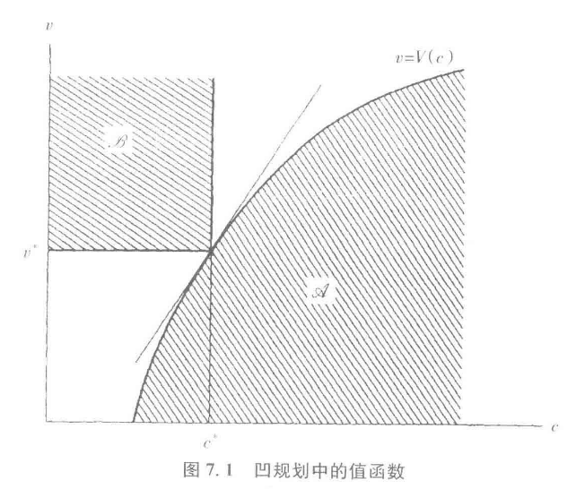

## 分离性质

- 集合A是所有满足$v \leq V(c)$的点$(c, v)$的集合，意味着使用投入向量$c$进行生产，生产出的产品至少能带来$v$的收入
- 在集合A中选择一点$(c^*, v^*)$，使得$v^* = V(c^*)$，这必然是一个边界点
- 集合B是所有满足$c \leq c^*$和$v \geq v^*$的点$(c, v)$的集合

分离超平面：
$$\epsilon v - \lambda c = b = \epsilon v^* - \lambda c^*$$
其中$\epsilon$是一个标量，$\lambda$是一个m维向量，且满足
$$\epsilon v - \lambda c
\begin{cases}
\leq b, & \forall (c,v) \in A \\
\geq b, & \forall (c,v) \in B
\end{cases}$$

## 约束规格

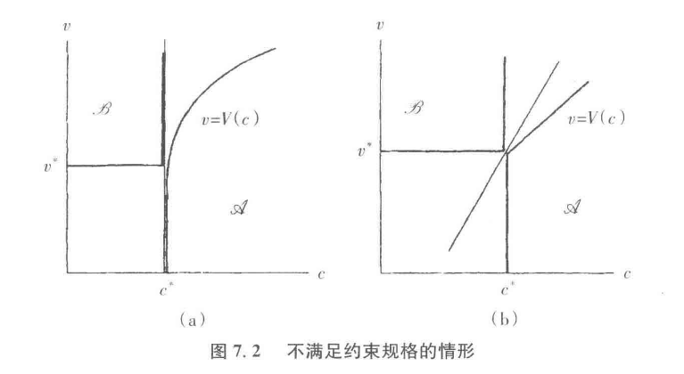

## 斯拉特条件

斯拉特条件：集合A至少存在一个内点$x_0$使得$G(x_0) \ll c^*$，即$x_0$满足所有约束条件且严格不等式成立

**证明思路：**

- 假设存在$x_0$满足所有约束严格不等式 - 当$\epsilon = 0$时推导矛盾
- 得出结论$\epsilon > 0$

关键等式：
$$\lambda(G(x_0) - c^*) = \sum_{i=1}^m \lambda_i(G^i(x_0) - c_i^*) < 0$$

## 影子价格

- 令$\epsilon = 1$，则$\lambda$解释为投入要素的影子价格
- 最大值函数$V$的可微性导致$\lambda = V_c(c^*)$
- 当$V$不可微时，存在双边不等式：
  $$V_i^- \geq \lambda_i \geq V_i^+$$

## 一般化的边际产品

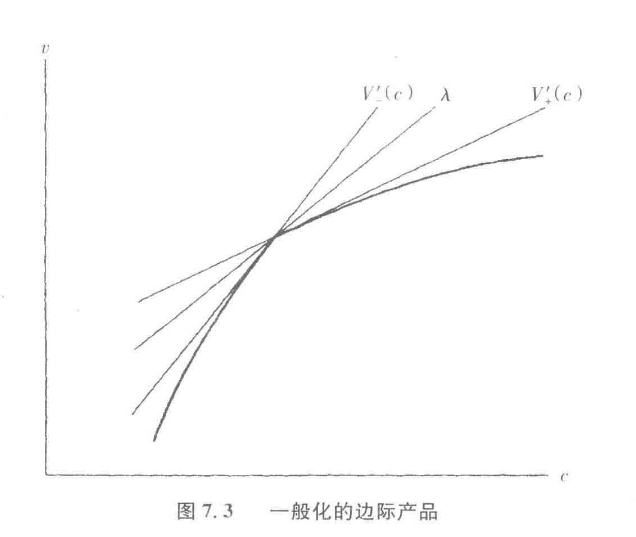

## 选择变量

通过分离定理推导关键不等式：
$$F(\bar{x}) - \lambda G(\bar{x}) \leq V(c) - \lambda c$$

结合互补松弛条件：

- 对于每个约束$i$，$\lambda_i[c_i - G^i(\bar{x})] = 0$
- 要么$\lambda_i = 0$，要么$G^i(\bar{x}) = c_i$

## 凹规划的必要条件

若$\bar{x}$是凹规划问题的最优解，存在向量$\lambda$满足：

- $\bar{x}$在无约束下最大化$F(x) - \lambda G(x)$
- $\lambda \geq 0$且满足互补松弛条件
- 可微情形下的一阶条件：
  $$F_{x}(\bar{x}) - \lambda G_{x}(\bar{x}) = 0$$

## 凸规划的充分条件 I

若$\bar{x}$满足：

- 最大化$F(x) - \lambda G(x)$
- 满足互补松弛条件

则对任意可行$x$有：
$$F(\bar{x}) \geq F(x)$$

利用凹函数性质：
$$[F(x) - \lambda G(x)] - [F(\bar{x}) - \lambda G(\bar{x})] \leq 0$$

## 凹规划的充分条件 II

若$\bar{x}$和$\lambda$满足以下条件：

- $\bar{x}$在无约束的情况下最大化了$F(x) - \lambda G(x)$
- $\lambda \geq 0$和$G(\bar{x}) \leq c$满足互补松弛条件

## 拟凹规划 ($F$拟凹，$G$为线性函数)

如果$F$为拟凹函数，那么
$$\begin{aligned}
F((1 - \theta) x^a + \theta x^b) \geq \min(F(x^a), F(x^b))
\end{aligned}$$

假定$F(x^b) \geq F(x^a)$，那么
$$F(x^a + \theta(x^b - x^a)) \geq F(x^a)$$

将上式看作关于$\theta$的函数：
$$h(\theta) \geq h(0), \quad \forall \theta \in [0,1]$$

通过链式法则推导：
$$\begin{aligned}
h'(\theta) &= F_x(x^a + \theta (x^b - x^a))(x^b - x^a) \\
h'(0) &= F_x(x^a)(x^b - x^a) \geq 0
\end{aligned}$$

## 拟凹规划 II

考虑在线性约束$px \leq b$下最大化$F(x)$，最优解必要条件为：
$$F_x(\bar{x}) - \lambda p = 0$$

**充分性证明：** 对任意满足$F(x) > F(\bar{x}) \equiv \bar{v}$的$x$，取$x^a = \bar{x}$和$x^b = x$，由拟凹性可得：
$$F_x(\bar{x})(x - \bar{x}) \geq 0$$

## 拟凹规划 III

结合必要条件推导：
$$p(x - \bar{x}) \geq 0 \Rightarrow px \geq p\bar{x}$$

反证结论：

- 若$px = p\bar{x}$，则$x$在满足约束下得到更大$F$，矛盾
- 故必有$px > p\bar{x}$，即$x$不可行